# R Intermediate 1: Introduction to for loops

Andrew Moles

Learning Developer, Digital Skills Lab

16 February, 2024

# Objective of workshop

To start writing for loops to perform iteration, which is the act of sequentially repeating your code, to streamline data cleaning and analysis.

# What this workshop will cover

In this workshop, the aim is to cover how to start working with for loops. This will primarily include:

- The logic behind a simple for loop
- Executing for loops
- Executing conditional for loops
- Looping through data frames

# For loop basics part 1

In programming, *looping* is a fundamental concept. When you *loop*, you are repeating your code a number of times. This is advantageous as it saves you typing the same code numerous times!

A for loop is one of the main looping techniques widely used to sequentially select each element from a collection and carry out a set of commands with the currently selected element.

Every for loop is defined by the collection from which to select elements sequentially, and the variable name for the currently selected element. To put it more practically, the idea is to understand: a) From which vector (or another collection) do we select elements? b) What should the currently selected element be called?

We translate these questions into R code with the `for` and `in` keyword. Have a look at line 3 in the below code cell. What is the collection from which elements are being sequentially selected and what is the variable name used for the currently selected element? Think a moment before reading on.

`my_vector` is the collection that we select elements from. `number` is being used as the variable name for the currently selected element. In programming, we call this process of selecting elements with a for loop, to loop over `my_vector` or iterating through `my_vector`.

At the end of the `for` statement we use `{}`. All the commands that should be repeated in the for loop have to be indented following the `for` statement. Consequently, `print(number)` is part of the for loop, while `print('end of for loop')` is not as it is outside of the `{}`.

The for loop takes each number from `my_vector`, assigns the value to the variable `number` and then prints it. After having looped over all numbers from `my_vector` the for loop ends and R continues with the print statement in line 6.

```r
my_vector <- 1:3

for (number in my_vector){
  print(number)
}
```

```
## [1] 1
## [1] 2
## [1] 3
```

```r
print("End of for loop")
```

```
## [1] "End of for loop"
```

Check this (very fun) flow diagram below to process the intuition.

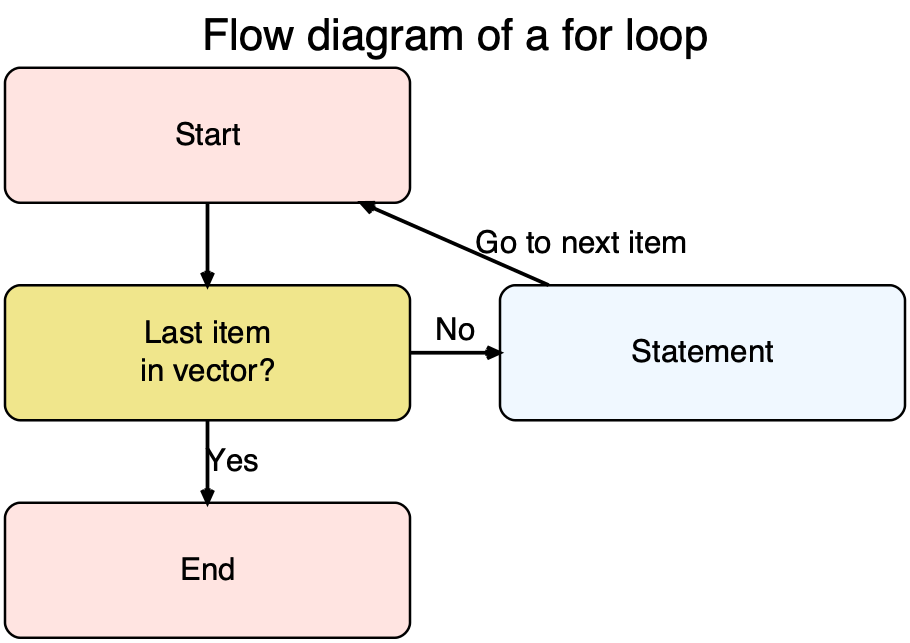

## For loop basics exercise 1

Make your first for loop! What would be the output of the for loop if we changed the numbers of my vector to 1 through to 5, and printed the numbers twice? Test it out.

1. Create a vector called `my_vector` with the numbers 1 through to 5
2. Make a for loop using `my_vector` and print each number twice
3. Add a print statement outside the loop to tell us the for loop has ended

```r
# your code here
my_vector <- 1:5

for (number in my_vector){
  print(number)
  print(number)
}
```

```
## [1] 1
## [1] 1
## [1] 2
## [1] 2
## [1] 3
## [1] 3
## [1] 4
## [1] 4
## [1] 5
## [1] 5
```

```r
print("end of for loop")
```

```
## [1] "end of for loop"
```

# For loop basics part 2

**When writing for loops in R there are three golden rules:**

1. Don’t use a for loop if a vectorised or functional alternative exists
2. Don’t grow objects in a for loop as this slows things down a lot. R will make a new object, then copy information which isn’t very efficient
3. Always make an empty data structure before the loop, then fill it during the loop

We will elaborate on these rules as we go through this worksheet!

When needed, loops allow us to write more efficient code, which in a lot of cases means less repetition and use of copy and paste.

Take the below example. We want to do calculations with a vector and a variable, and write the result of each step as a string (e.g. `"5*12 = 60"`). In this case we are working out the 12 times table.

As you can see, this is a bit repetitive and impractical, forcing us to write indexes manually which is not ideal!

```r
# vectors of numbers
a <- c(5, 7, 1, 3, 11)
b <- 12
# empty vector
c <- rep(0, length(a))
# calculations
c[1] <- paste0(a[1], "*", b, " = ", a[1]*b)
c[2] <- paste0(a[2], "*", b, " = ", a[2]*b)
c[3] <- paste0(a[3], "*", b, " = ", a[3]*b)
c[4] <- paste0(a[4], "*", b, " = ", a[4]*b)
c[5] <- paste0(a[5], "*", b, " = ", a[5]*b)
# print result
c
```

```
## [1] "5*12 = 60"   "7*12 = 84"   "1*12 = 12"   "3*12 = 36"   "11*12 = 132"
```

This is where the for loop comes in! It streamlines our code and removes any manual elements.

The loop takes the first element from `a`, assigns the value to the variable `number`. It then, within the `paste0()` function performs a calculation, then assigns it to the first element of `c`. It then repeats this process for the second, third, fourth elements and so on till there are no more elements left.

As a bonus, we could add extra elements to `a` and the code would still work. Have a go at adding some more strings to the `a` vector to try it different values of the 12 times table.

*Note, making an empty data structure (e.g. a variable, vector, or data frame) before looping, then adding to that data structure is the best practice, like we did here with c*

```r
# vectors of numbers
a <- c(5, 7, 1, 3, 11)
b <- 12
# empty vector
c <- rep(NA, length(a))
# for loop to do calculations and export as strings
for (number in seq_along(a)){
  c[number] <- paste0(a[number], "*", b, " = ", a[number]*b)
}
# print result
c
```

```
## [1] "5*12 = 60"   "7*12 = 84"   "1*12 = 12"   "3*12 = 36"   "11*12 = 132"
```

Notice we added the `seq_along()` function with our looping through vector `a`. Why do we need it? It is a safe way of ensuring predictable behaviour when creating a sequence of numbers or vectors. In the code cell below, notice the difference between how `seq_along()` and `seq()` behave when given a variable with a length of 1. We don’t want this duplication happening when running a for loop, and `seq_along()` helps to control that behaviour.

```r
a <- c(8, 9, 10)
b <- 10
# seq_along behaviour
seq_along(a)
```

```
## [1] 1 2 3
```

```r
seq_along(b)
```

```
## [1] 1
```

```r
# seq behaviour
seq(a)
```

```
## [1] 1 2 3
```

```r
seq(b)
```

```
##  [1]  1  2  3  4  5  6  7  8  9 10
```

Now that you are acquainted with the logic (for) for loop, seq, and seq_along, try and work through the flow diagram below to process the intuition. Once you have this clear, you can write a loop in any programming language with ease!

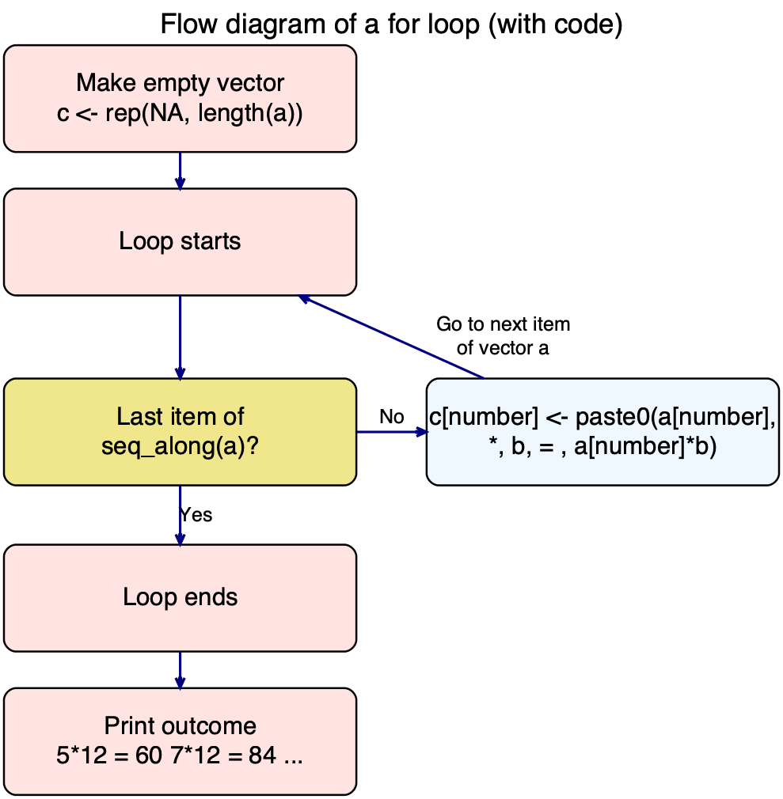

## For loop basics exercise 2

Using the animals and people variables provided, write a for loop that pairs up a variable from `animals` with a variable for `people` for each element of `animals`, which makes the result into a string such as `"Amelia owns a Cat"`.

You will have to make an empty vector first, which can be called `pairings`. Then write the for loop to add the pairs to your `pairings` variable.

Print the output at the end to review. `pairings` should end up with something like: `"Amelia owns a Cat" "Noah owns a Fish" "Oliver owns a Bird" "George owns a Dog" "Olivia owns a Rabbit"`.

```r
animals <- sample(c("Dog", "Cat", "Fish", "Bird", "Rabbit"))
people <- sample(c("Noah", "Olivia", "Oliver", "George", "Amelia"))

# your code here
pairings <- rep(NA, length(animals))

for (pets in seq_along(1:length(animals))) {
  pairings[pets] <- paste(people[pets], "owns a", animals[pets])
}

pairings
```

```
## [1] "Oliver owns a Fish" "George owns a Bird" "Noah owns a Rabbit"
## [4] "Olivia owns a Dog"  "Amelia owns a Cat"
```

# For loop with break or next

In R, the break keyword is used to exit a loop prematurely. When the break statement is encountered within a loop, it immediately terminates the loop. The execution then continues with the next statement after the loop. Work through below example to understand the logic.

```r
# Use a for loop to iterate over a vector
for (i in 1:10) {
  # If i is greater than 5, exit the loop
  if (i > 5) {
    cat("Exiting loop\n")
    break
  }
  # Print the current value of i
  cat("i is", i, "\n")
}
```

```
## i is 1
## i is 2
## i is 3
## i is 4
## i is 5
## Exiting loop
```

```r
# Print a message after the loop has exited
cat("Loop finished\n")
```

```
## Loop finished
```

You can use the break keyword in a similar way with a while loop or other types of loops in R. Just be careful not to overuse break, as it can make your code harder to read and debug.

Similar to break is the *next* keyword. Unlike break, it skips the matched condition and then continues the loop. Run the code and review the output to understand the logic.

```r
# Use a for loop to iterate over a vector
for (i in 1:10) {
  # If i is greater than 5, exit the loop
  if (i > 5 & i < 8) {
    cat("Skipping\n")
    next
  }
  # Print the current value of i
  cat("i is", i, "\n")
}
```

```
## i is 1
## i is 2
## i is 3
## i is 4
## i is 5
## Skipping
## Skipping
## i is 8
## i is 9
## i is 10
```

```r
# Print a message after the loop has exited
cat("Loop finished\n")
```

```
## Loop finished
```

## For loop with break and next exercise

Using the vector `ages` provided, write two for loops. The first will break when an age is under 17. The second will skip to the next valid case when an age is under 17.

On each *iteration* your loop should print out something like “Age 18: can drive”. When age is less than 17 your loop should print “Age 16: can’t drive, breaking loop” or “Age 16: can’t drive, moving on”.

Use the previous examples to help you write the code.

```r
ages <- c(18, 21, 19, 17, 16, 18, 23)
ages
```

```
## [1] 18 21 19 17 16 18 23
```

```r
# your code here

# loop with break
for (age in seq_along(ages)) {
  if (ages[age] < 17) {
    print(paste0("Age ", ages[age], ": can't drive, breaking loop"))
    break
  }
  print(paste0("Age ", ages[age], ": can drive"))
}
```

```
## [1] "Age 18: can drive"
## [1] "Age 21: can drive"
## [1] "Age 19: can drive"
## [1] "Age 17: can drive"
## [1] "Age 16: can't drive, breaking loop"
```

```r
print("Loop finished")
```

```
## [1] "Loop finished"
```

```r
# loop with next
for (age in seq_along(ages)) {
  if (ages[age] < 17) {
    print(paste0("Age ", ages[age], ": can't drive, moving on"))
    next
  }
  print(paste0("Age ", ages[age], ": can drive"))
}
```

```
## [1] "Age 18: can drive"
## [1] "Age 21: can drive"
## [1] "Age 19: can drive"
## [1] "Age 17: can drive"
## [1] "Age 16: can't drive, moving on"
## [1] "Age 18: can drive"
## [1] "Age 23: can drive"
```

```r
print("Loop finished")
```

```
## [1] "Loop finished"
```

# For loop with conditions

For loops are particularly useful when combined with conditional statements like the if statement.

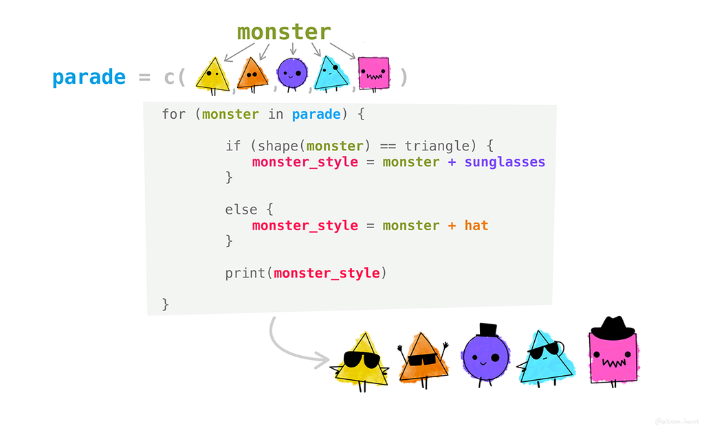

For loop example from Allison Horst using for loop to conditionally add hats or sunglasses to monsters

In this below example, for each element of `run_time` our for loop will test the conditions of our if statement, and print out the result for each element of `run_time`. Run the code to test it out.

```r
# running times vector
run_time <- c(15, 30, 22, 25, 45, 12, 53, 34)
# empty vector for category
run_category <- rep(NA, length(run_time))

# looping through run_time, printing when a condition is met and added to vector
for (run in seq_along(run_time)){
  if (run_time[run] >= 25 & run_time[run] <= 35){
    run_category[run] <- "Medium length run"
    print(run_category[run])
    }
  else if (run_time[run] < 25){
    run_category[run] <- "Short length run"
    print(run_category[run])
  }
  else {
    run_category[run] <- "Long length run"
    print(run_category[run])
  }
}
```

```
## [1] "Short length run"
## [1] "Medium length run"
## [1] "Short length run"
## [1] "Medium length run"
## [1] "Long length run"
## [1] "Short length run"
## [1] "Long length run"
## [1] "Medium length run"
```

```r
# print whole vector
run_category
```

```
## [1] "Short length run"  "Medium length run" "Short length run"
## [4] "Medium length run" "Long length run"   "Short length run"
## [7] "Long length run"   "Medium length run"
```

## For loop with conditionals exercise

Have a go at adding conditional statements to a for loop by trying out a classic programming test - the fizzbuzz programme.

Write a for loop that prints the numbers from 1 to 25. For multiples of “3”, print “Fizz” instead of the number. For multiples of “5”, print “Buzz”. For multiples of “3” and “5”, print “FIZZBUZZ”. Assign the results of each loop back to the `fizzbuzz` variable, then print that variable outside of the loop.

*Hint: a multiple of 3 would have a remainder of 0. E.g. the remainder of 3/3 is 0*.

*Further hint: `%%` gives you the remainder, also called the modulus operator.*

```r
count <- 1:25

fizzbuzz <- rep(NA, length(count))

# your code here
for (each in seq_along(count)) {
  if (count[each] %% 3 == 0 & count[each] %% 5 == 0){
    fizzbuzz[each] <- "FIZZBUZZ"
    print(fizzbuzz[each])
  }
  else if (count[each] %% 3 == 0){
    fizzbuzz[each] <- "Fizz"
    print(fizzbuzz[each])
  }
  else if (count[each] %% 5 == 0){
    fizzbuzz[each] <- "Buzz"
    print(fizzbuzz[each])
  }
  else {
    fizzbuzz[each] <- count[each]
    print(fizzbuzz[each])
  }
}
```

```
## [1] 1
## [1] 2
## [1] "Fizz"
## [1] "4"
## [1] "Buzz"
## [1] "Fizz"
## [1] "7"
## [1] "8"
## [1] "Fizz"
## [1] "Buzz"
## [1] "11"
## [1] "Fizz"
## [1] "13"
## [1] "14"
## [1] "FIZZBUZZ"
## [1] "16"
## [1] "17"
## [1] "Fizz"
## [1] "19"
## [1] "Buzz"
## [1] "Fizz"
## [1] "22"
## [1] "23"
## [1] "Fizz"
## [1] "Buzz"
```

```r
fizzbuzz
```

```
##  [1] "1"        "2"        "Fizz"     "4"        "Buzz"     "Fizz"
##  [7] "7"        "8"        "Fizz"     "Buzz"     "11"       "Fizz"
## [13] "13"       "14"       "FIZZBUZZ" "16"       "17"       "Fizz"
## [19] "19"       "Buzz"     "Fizz"     "22"       "23"       "Fizz"
## [25] "Buzz"
```

You can run this logic in any programming language, and is a good way to test out your knowledge of loops and conditionals in that language.

# Looping through a data frame

In R, the most common data type is a data frame. So you can tell, that learning how to use a for loop with a data frame is a very useful skill. For the rest of the examples in this tutorial we will be using the Palmers penguins dataset - https://allisonhorst.github.io/palmerpenguins/.

First we will need to install the package that holds the dataset.

```r
install.packages("palmerpenguins")
```

Now we load the package and have a quick look at the data. Note when loading a dataset from a package is can be helpful to use the `data()` function, which loads it into your global environment. Run the code and you should see penguins and penguins_raw appear in the global environment (usually right hand side of RStudio).

```r
# load library
library(palmerpenguins)
# load data to environment
data(penguins)
# review data
head(penguins)
```

```
## # A tibble: 6 × 8
##   species island    bill_length_mm bill_depth_mm flipper_length_mm body_mass_g
##   <fct>   <fct>              <dbl>         <dbl>             <int>       <int>
## 1 Adelie  Torgersen           39.1          18.7               181        3750
## 2 Adelie  Torgersen           39.5          17.4               186        3800
## 3 Adelie  Torgersen           40.3          18                 195        3250
## 4 Adelie  Torgersen           NA            NA                  NA          NA
## 5 Adelie  Torgersen           36.7          19.3               193        3450
## 6 Adelie  Torgersen           39.3          20.6               190        3650
## # ℹ 2 more variables: sex <fct>, year <int>
```

We might be interested to find out the mean, median, and range of certain columns in our penguins data. We can make an aggregate table of these columns using a for loop. We first select the columns we are interested in. Here we have selected the bill_length_mm and bill_depth_mm columns (column 3 and 4).

Next we make an empty data frame for our summary statistics to go into, setting the column names as the descriptive statistics used (mean, median etc.). Then we add the column names we have selected as row names.

Finally, we loop through the selected columns in our penguins data. On each loop we calculate the mean, median etc. for each column and save the result into our `penguin_stats` data frame. The indexing is important here, we are using the selected element (`stats`) to tell R where to extract and add data.

```r
# select the names columns we are interested in and review
cols <- names(penguins[, c("bill_length_mm", "bill_depth_mm")])
cols
```

```
## [1] "bill_length_mm" "bill_depth_mm"
```

```r
# Make a empty data frame based on number of columns
penguins_stats <- data.frame(
  means = rep(NA, length(cols)),
  medians = rep(NA, length(cols)),
  min = rep(NA, length(cols)),
  max = rep(NA, length(cols))
)

# add the columns as row names
rownames(penguins_stats) <- cols

# review data frame pre-loop
penguins_stats
```

```
##                means medians min max
## bill_length_mm    NA      NA  NA  NA
## bill_depth_mm     NA      NA  NA  NA
```

```r
# loop through selected cols from penguins, performing statistics
for (stats in seq_along(penguins[, cols])){
  penguins_stats[stats, "means"] <- mean(penguins[, cols[stats], drop = TRUE], na.rm = TRUE)
  penguins_stats[stats, "medians"] <- median(penguins[, cols[stats], drop = TRUE], na.rm = TRUE)
  penguins_stats[stats, "min"] <- min(penguins[, cols[stats], drop = TRUE], na.rm = TRUE)
  penguins_stats[stats, "max"] <- max(penguins[, cols[stats], drop = TRUE], na.rm = TRUE)
}

# print outcome
penguins_stats
```

```
##                   means medians  min  max
## bill_length_mm 43.92193   44.45 32.1 59.6
## bill_depth_mm  17.15117   17.30 13.1 21.5
```

You might notice that how we indexed our statistical functions was slightly different, as we included the `drop = TRUE`. Without `drop = TRUE` our output is a data frame, which the `mean()` function struggles to work with. With `drop = TRUE` it makes the selected column into a vector, allowing the `mean()` function to work.

Example without the `drop = TRUE` argument.

```r
# without the drop = TRUE
mean(penguins[1:5, "body_mass_g"],
     na.rm = TRUE)
```

```
## [1] NA
```

Example with the `drop = TRUE` argument.

```r
# with the drop = TRUE
mean(penguins[1:5, "body_mass_g", drop = TRUE],
     na.rm = TRUE)
```

```
## [1] 3562.5
```

R is a functional language, which means a lot of the time other people have written for loops like the one above for us which are wrapped in functions.

For example, the base R `summary()` function provides us with a summary of selected columns. This is one of the nice things about R. You don’t always have to write for loops and can use functions most of the time. This can make your coding easier and faster. When you get more comfortable, you can start writing your own for loops and functions, which provide more flexibility.

```r
summary(penguins[, cols])
```

```
##  bill_length_mm  bill_depth_mm
##  Min.   :32.10   Min.   :13.10
##  1st Qu.:39.23   1st Qu.:15.60
##  Median :44.45   Median :17.30
##  Mean   :43.92   Mean   :17.15
##  3rd Qu.:48.50   3rd Qu.:18.70
##  Max.   :59.60   Max.   :21.50
##  NA's   :2       NA's   :2
```

## Looping through a data frame exercise

Adapt the code we used above to include the following:

1. The columns “bill_length_mm”, “bill_depth_mm”, “flipper_length_mm”, and “body_mass_g”
2. The following descriptive statistics: `median()`, standard deviation `sd(),` and the interquartile range `IQR()`

Skeleton code has been provided. Feel free to copy and paste sections from the example to adapt the code.

```r
# select the names columns we are interested in
cols <- names(penguins[, c()])

# Make a empty data frame based on number of columns
penguins_stats <- data.frame(
  medians = rep(NA, length(cols))
)

# add the columns as row names
rownames(penguins_stats) <- cols

# loop through selected cols from penguins, doing descriptive statistics
for (variable in vector) {
  # median
  # sd
  # IQR
}
```

```
## Error in for (variable in vector) {: invalid for() loop sequence
```

```r
# print outcome
penguins_stats
```

```
## [1] medians
## <0 rows> (or 0-length row.names)
```

```r
# solution!
# select the names columns we are interested in
cols <- names(penguins[, c("bill_length_mm", "bill_depth_mm",
                           "flipper_length_mm", "body_mass_g")])

# Make a empty data frame based on number of columns
penguins_stats <- data.frame(
  medians = rep(NA, length(cols)),
  sds = rep(NA, length(cols)),
  iqrs = rep(NA, length(cols))
)

# add the columns as row names
rownames(penguins_stats) <- cols

# loop through selected cols from penguins, doing descriptive statistics
for (stats in seq_along(penguins[, cols])){
  # median
  penguins_stats[stats, "medians"] <- median(penguins[, cols[stats], drop = TRUE], na.rm = TRUE)
  # sd
  penguins_stats[stats, "sds"] <- sd(penguins[, cols[stats], drop = TRUE], na.rm = TRUE)
  # IQR
  penguins_stats[stats, "iqrs"] <- IQR(penguins[, cols[stats], drop = TRUE], na.rm = TRUE)
}

# print outcome
penguins_stats
```

```
##                   medians        sds     iqrs
## bill_length_mm      44.45   5.459584    9.275
## bill_depth_mm       17.30   1.974793    3.100
## flipper_length_mm  197.00  14.061714   23.000
## body_mass_g       4050.00 801.954536 1200.000
```

# Looping for visualising

Our next example is an extension of the above examples. The idea of the exercise is to traverse the dataset to display further statistical properties - this time in the form of visualizations - specifically, histograms.

For our visualisation we are using the `hist()` function, which produces a histogram. Our code will produce a histogram for each selected column, and will add the title and x label of that column.

Try running the below code and review the output.

```r
# review which columns have integer or numeric data
str(penguins)
```

```
## tibble [344 × 8] (S3: tbl_df/tbl/data.frame)
##  $ species          : Factor w/ 3 levels "Adelie","Chinstrap",..: 1 1 1 1 1 1 1 1 1 1 ...
##  $ island           : Factor w/ 3 levels "Biscoe","Dream",..: 3 3 3 3 3 3 3 3 3 3 ...
##  $ bill_length_mm   : num [1:344] 39.1 39.5 40.3 NA 36.7 39.3 38.9 39.2 34.1 42 ...
##  $ bill_depth_mm    : num [1:344] 18.7 17.4 18 NA 19.3 20.6 17.8 19.6 18.1 20.2 ...
##  $ flipper_length_mm: int [1:344] 181 186 195 NA 193 190 181 195 193 190 ...
##  $ body_mass_g      : int [1:344] 3750 3800 3250 NA 3450 3650 3625 4675 3475 4250 ...
##  $ sex              : Factor w/ 2 levels "female","male": 2 1 1 NA 1 2 1 2 NA NA ...
##  $ year             : int [1:344] 2007 2007 2007 2007 2007 2007 2007 2007 2007 2007 ...
```

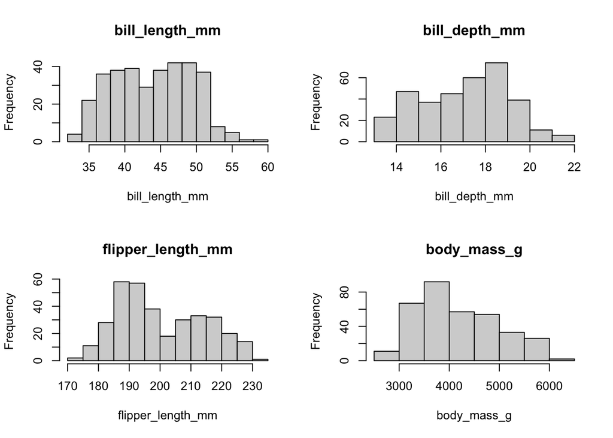

```r
# select columns
cols <- names(penguins[, c("bill_length_mm", "bill_depth_mm",
                           "flipper_length_mm", "body_mass_g")])

# filtered data by columns
penguins_filt <- penguins[, cols]

# make plotting grid
par(mfrow = c(2,2))
# for each column, make a plot
for (col in colnames(penguins_filt)) {
  x <- penguins_filt[[col]]
  hist(x, main = col, xlab = col)
}
```

Cool! We just made several visualisations in a nice and clean way. This technique is particularly useful when you want to explore a dataset before analysis.

## Looping for visualising exercise

Now it is your turn! We will be using Broadway data, which tells us weekly box office figures for all Broadway shows since the 80’s.

More information about the data can be found here: https://github.com/rfordatascience/tidytuesday/blob/master/data/2020/2020-04-28/readme.md

This exercise is in two parts. The first we will make histograms, the second we will make scatter plots.

For the first part of the exercise, we will just look at data for *Les Miserables* - one of the most successful musicals of all time.

The task is to make histograms for the following columns in the dataset: `weekly_gross`, `avg_ticket_price`, `pct_capacity`, and `performances`.

If you have reviewed the above example thoroughly, you are in a good place to try out the challenge! Come back to the hint below if you are stuck.

*Hint: You will need to first select all shows that are Les Miserables, then subset the data to contain just the columns of interest.*

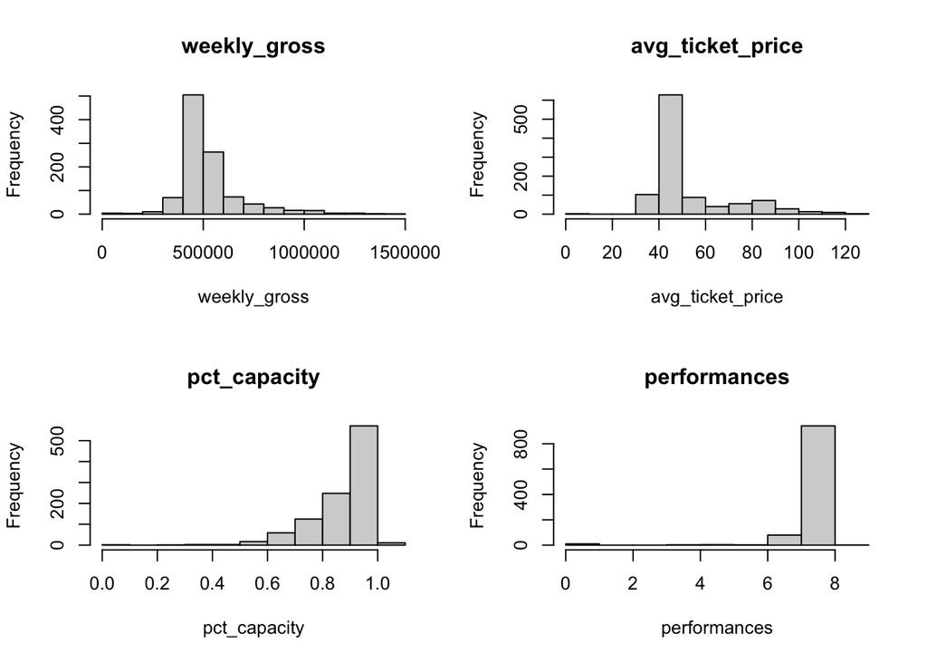

```r
broadway_grosses <- read.csv('https://raw.githubusercontent.com/rfordatascience/tidytuesday/master/data/2020/2020-04-28/grosses.csv')

# your code here
les_mis <- subset(broadway_grosses, show == "Les Miserables")

cols <- c("weekly_gross", "avg_ticket_price",
                          "pct_capacity", "performances")

# filtered data by columns
les_mis_filt <- les_mis[, cols]

# make plotting grid
par(mfrow = c(2,2))

# for each column, make a plot
for (col in colnames(les_mis_filt)) {
  x <- les_mis_filt[[col]]
  hist(x, main = col, xlab = col)
}
```

Now, we can try to explore the relationship between `avg_ticket_price` and `pct_capacity`, which might be an interesting interaction!

For this exercise, we will expand our analysis to cover a few more classics. Namely, *The Phantom of the Opera, Chicago, The Lion King*, and of course, *Les Miserables*.

1. Subset your `broadway_grosses` data to just contain the classic shows listed above
2. Set up `par()` to be a 2 by 2 grid like we did previously
3. Using a for loop make a scatter plot of `pct_capacity` and `avg_ticket_price` for each of our classic shows
4. Review the output. Do you see any trends?

*Hint 1:* To make a scatter plot we use the `plot()` function with something like `plot(x ~ y, data = z)`

*Hint 2:* You will need to subset your data within the for loop

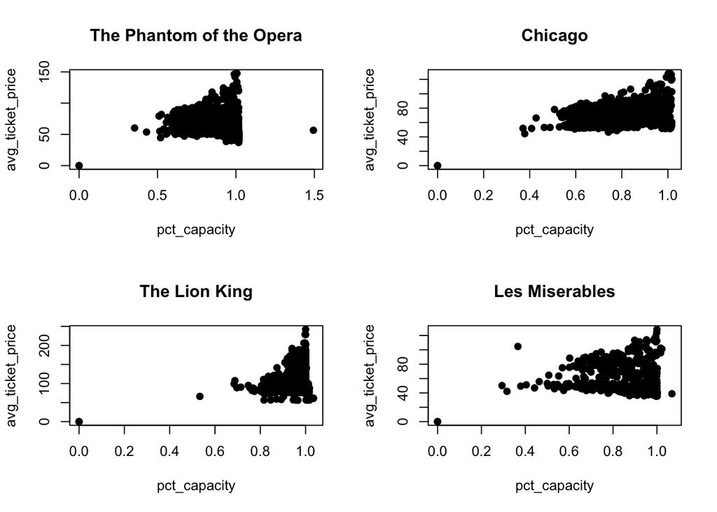

```r
# your code here

# solution!
selected_shows <- c("The Phantom of the Opera", "Chicago", "The Lion King", "Les Miserables")

top_shows <- subset(broadway_grosses, show %in% selected_shows)

par(mfrow = c(2,2))

for (show_name in selected_shows) {
  x <- subset(top_shows, show == show_name)
  plot(avg_ticket_price ~ pct_capacity,
       data = x,
       main = unique(show),
       pch = 19)
}
```

# Some useful resources

https://www.datacamp.com/tutorial/tutorial-on-loops-in-r

https://discdown.org/rprogramming/loops.html

https://r.qcbs.ca/workshop05/book-en/for-loops.html

https://www.datamentor.io/r-programming/while-loop

# While loops

This workshop has focused on the for loop as a tool to repeat code. Another option is the while loop, which repeats the specified code until a condition is met. They are particularly useful when you have some user input needed, and you do not know how many times you will need to repeat the code. Generally speaking, while loops are rare in R but can be useful to know, especially if you are planning to use other programming languages in the future.

Why did our while loop print 1 to 5?

```r
# variable
x <- 1

while (x < 6) {
  # print our variable
  print(x)
  # update expression
  x <- x + 1
}
```

```
## [1] 1
## [1] 2
## [1] 3
## [1] 4
## [1] 5
```

One word of caution on using while loops, if the condition is never met, the while loop will run forever!

Another example of a while loop in action, is a dice rolling programme. Run the code and review the output.

Why did the code stop when it did? What was the output when the code stopped?

```r
dice_roll <- 0

while(dice_roll != 6) {
  dice_roll <- sample(1:6, 1, replace = TRUE)
  print(paste("You rolled a", dice_roll))
}
```

```
## [1] "You rolled a 4"
## [1] "You rolled a 2"
## [1] "You rolled a 2"
## [1] "You rolled a 2"
## [1] "You rolled a 3"
## [1] "You rolled a 5"
## [1] "You rolled a 2"
## [1] "You rolled a 4"
## [1] "You rolled a 2"
## [1] "You rolled a 3"
## [1] "You rolled a 5"
## [1] "You rolled a 1"
## [1] "You rolled a 2"
## [1] "You rolled a 4"
## [1] "You rolled a 3"
## [1] "You rolled a 5"
## [1] "You rolled a 4"
## [1] "You rolled a 3"
## [1] "You rolled a 1"
## [1] "You rolled a 5"
## [1] "You rolled a 2"
## [1] "You rolled a 6"
```

## While loop exercise

For this exercise, we will be debugging some code to get it running! This code is for randomly generating data, and uses a while loop to do that.

There are 4 errors to find in total. If you get the code to run, you should get a box plot as the output!

```r
# data
my_words <- c("coding", "R", "fun", "is", "really")
# empty vectors
all_words <- c()
n <- c()

# while loop
while (lenght(words) < 50) {

  s <- sample(1:5, size = 1)
  w <- my_words[samp]

  all_words <- c(all_words, w)
  n <- (n, sample(1:10, 1))
}

# put into data frame
word_data <- data.frame(
  n,
  all_words = factor(all_words, levels = c("R", "coding", "is", "really", "fun"))
  )

# plot outcome
plot(x = word_data$all_words,
     y = word_data$n)
```

```
## Error: <text>:14:10: unexpected ','
## 13:   all_words <- c(all_words, w)
## 14:   n <- (n,
##              ^
```

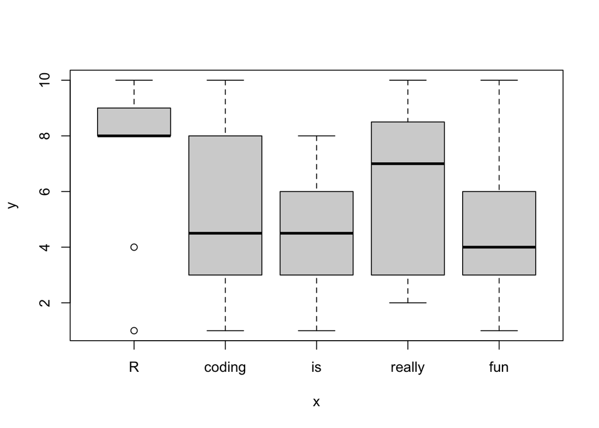

```r
# solution!
# data
my_words <- c("coding", "R", "fun", "is", "really")
# empty vectors
all_words <- c()
n <- c()

# while loop
while (length(all_words) < 50) {

  s <- sample(1:5, size = 1)
  w <- my_words[s]

  all_words <- c(all_words, w)
  n <- c(n, sample(1:10, 1))
}

# put into data frame
word_data <- data.frame(
  n,
  all_words = factor(all_words, levels = c("R", "coding", "is", "really", "fun"))
  )

# plot outcome
plot(x = word_data$all_words,
     y = word_data$n)
```

# Final task - Please give us your individual feedback!

We would be grateful if you could take a minute before the end of the workshop so we can get your feedback!

https://lse.eu.qualtrics.com/jfe/form/SV_6eSrOVWuit28qcS?coursename=R%Intermediate%1:%Introduction%to%for%loops&topic=R&prog=DS&version=23-24&link=https://lsecloud.sharepoint.com/:f:/s/TEAM_APD-DSL-Digital-Skills-Trainers/Es1aaTE7_g9ClbjG_R0A87IBJanmSZ-vDdM2gJfEcWahhg?e=gtECWp

The solutions we be available from a link at the end of the survey.

# Individual coding challenge

For the individual coding challenge we are going to use loops to automate a small analysis pipeline using simple linear regressions, bringing together ideas and concepts of what we have covered so far.

Some code has been provided to help you along the way!

## Part 1 - Using loops to load in data

We have an Excel file, called `top_shows.xlsx`, which has our data stored in multiple sheets. The column names are the same for each sheet. Each sheet represents a different Broadway show.

1. Load in the readxl library
2. Make a variable called `path` which is the pathway to your `top_shows.xlsx` file
3. Make a variable called `sheets`, using the `excel_sheets()` function, from readxl, with your path variable to extract the sheet names from your file.
4. Make an empty list called `broadway` or similar
5. Write a for loop that for every element in `seq_along(sheets)` will load that data into your empty list variable. Use the `read_excel()` function and iterate over the sheet argument
6. Now your data is loaded into your list, you can add names to those datasets. Using the names function add the names from your `sheets` variable to the datasets in your list. *hint: this is the same as assigning column names*
7. Finally, as all our column names are the same we can bind these datasets together. Using `rbind()`, combine the loaded datasets into a data frame and save the result as `top_broadway` or similar.

*Hint: if you have having trouble with the for loop, the scaffold code is provided below*

`for (i in seq_along(vector)) {list[[i]] <- read_excel(path, sheet = vector[[i]])}`

```r
# your code here

# load readxl
library(readxl)

# path to xlsx file
path <- "top_shows.xlsx"

# extract sheet information
sheets <- readxl::excel_sheets(path)

# loop to load in data
broadway <- list()

for (sheetname in seq_along(sheets)) {
  broadway[[sheetname]] <- read_excel(path, sheet = sheets[[sheetname]])
}

# add sheet names to datasets
names(broadway) <- sheets

# combine the datasets using rbind
top_broadway <- do.call(rbind, broadway)
```

Something else to note is there are three really nice alternatives to appending data frames from a list: `do.call()`, `bind_rows()` from dplyr, and `rbindlist()` from data.table.

- `do.call(rbind, broadway)`
- `dplyr::bind_rows(broadway)`
- `data.table::rbindlist(broadway)`

Try and do part 7 from the above exercises using the `do.call()` version.

## Part 2 - Review data

1. make a vector called `selected_cols` with the columns `weekly_gross_overall`, `avg_ticket_price`, `seats_sold`, and `performances`.
2. Filter your top_broadway data to include only your selected columns. Assign this filtered data to `top_broadway_filt`
3. Use `summary()` to review the summary statistics of your filtered data
4. Now we will make some plots comparing weekly_gross_overall to our independent variables using a for loop like we did previously. Remember to use `par()` so we can view them all at once.

*Hint:* plot will take a filtered dataset. If we gave the `plot()` function this code: `top_broadway_filt[, c(2, 1)]` what would it plot?

```r
# vector with columns of interest
selected_cols <- c("weekly_gross_overall", "avg_ticket_price",
                   "seats_sold", "performances")

# filtered data by columns
top_broadway_filt <- top_broadway[, selected_cols]

# summary statistics
summary(top_broadway_filt)
```

```
##  weekly_gross_overall avg_ticket_price   seats_sold     performances
##  Min.   : 2933761     Min.   :  0.00   Min.   :    0   Min.   :0.000
##  1st Qu.:10331272     1st Qu.: 53.19   1st Qu.: 8668   1st Qu.:8.000
##  Median :15002509     Median : 68.25   Median :11160   Median :8.000
##  Mean   :16804115     Mean   : 74.13   Mean   :10795   Mean   :7.928
##  3rd Qu.:22305181     3rd Qu.: 84.63   3rd Qu.:13096   3rd Qu.:8.000
##  Max.   :57807272     Max.   :242.15   Max.   :16319   Max.   :9.000
```

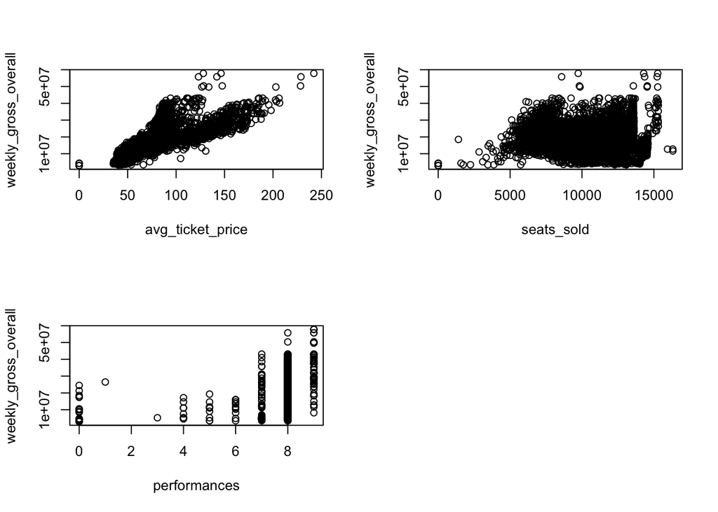

```r
# make scatter plots
par(mfrow = c(2,2))

for (col in seq(2,4, by = 1)) {
  plot(top_broadway_filt[, c(col, 1)])
}
```

## Part 3 - Analysis using regressions with some different variables

A really nice use case of loops is to iteratively add variables to a regression, allowing you to see the effect each addition has on the model. Here we are going to start with a simple linear regression, then build up to a multiple linear regression (still only 3 predictor variables). We will be using our prepared data from earlier `top_broadway_filt`.

1. First, we need to make an empty list called `model_summaries`. This is where out regression models will be stored.
2. Now we write the for loop that on each loop will add a new column from our `top_broadway_filt` data into the model, starting with weekly_gross_overall and avg_ticket_price. It should save the results back into model_summaries. Use this helpful blog post as a guide for you: https://statisticsglobe.com/r-multiple-regressions-in-for-loop
3. Check your results by printing model_summaries
4. Cool! We just run several regressions. We can now review the results. Using a for loop print out the adjusted R Squared of each model. Your output should look something like *Model 1 has adjusted R Squared of 0.603*. Hint: you can extract the adjusted R Squared with something like `model_summaries[[i]][["adj.r.squared"]]`
5. Another great way of looking at analysis results in R is using the `broom` package. Using this webpage as a source ,https://cran.r-project.org/web/packages/broom/vignettes/broom.html, how could you tidy up your results? Test out the `glance()` and `tidy()` functions.

```r
# loop over columns of Broadway to do build regression models
model_summaries <- list()

for (i in 2:ncol(top_broadway_filt)) {
  predictors_i <- colnames(top_broadway_filt)[2:i]
  model_summaries[[i - 1]] <- summary(lm(weekly_gross_overall ~ .,
       top_broadway_filt[ , c("weekly_gross_overall", predictors_i)]))
}

model_summaries
```

```
## [[1]]
##
## Call:
## lm(formula = weekly_gross_overall ~ ., data = top_broadway_filt[,
##     c("weekly_gross_overall", predictors_i)])
##
## Residuals:
##       Min        1Q    Median        3Q       Max
## -18258468  -3851660   -925579   2751777  28498245
##
## Coefficients:
##                  Estimate Std. Error t value Pr(>|t|)
## (Intercept)       -372968     210348  -1.773   0.0763 .
## avg_ticket_price   231710       2634  87.951   <2e-16 ***
## ---
## Signif. codes:  0 '***' 0.001 '**' 0.01 '*' 0.05 '.' 0.1 ' ' 1
##
## Residual standard error: 5580000 on 5099 degrees of freedom
## Multiple R-squared:  0.6027, Adjusted R-squared:  0.6026
## F-statistic:  7735 on 1 and 5099 DF,  p-value: < 2.2e-16
##
##
## [[2]]
##
## Call:
## lm(formula = weekly_gross_overall ~ ., data = top_broadway_filt[,
##     c("weekly_gross_overall", predictors_i)])
##
## Residuals:
##       Min        1Q    Median        3Q       Max
## -23677564  -2854241   -691109   2226399  26579737
##
## Coefficients:
##                    Estimate Std. Error t value Pr(>|t|)
## (Intercept)      8915242.20  325391.38   27.40   <2e-16 ***
## avg_ticket_price  248173.65    2411.34  102.92   <2e-16 ***
## seats_sold          -973.48      27.77  -35.05   <2e-16 ***
## ---
## Signif. codes:  0 '***' 0.001 '**' 0.01 '*' 0.05 '.' 0.1 ' ' 1
##
```

[output cut: 12 more lines]

```
##       Min        1Q    Median        3Q       Max
## -24055889  -2903412   -738478   2191598  25513186
##
## Coefficients:
##                    Estimate Std. Error t value Pr(>|t|)
## (Intercept)      -176367.48  869558.57  -0.203    0.839
## avg_ticket_price  245705.11    2392.25 102.709   <2e-16 ***
## seats_sold         -1028.26      27.87 -36.901   <2e-16 ***
## performances     1244379.29  110586.38  11.253   <2e-16 ***
## ---
## Signif. codes:  0 '***' 0.001 '**' 0.01 '*' 0.05 '.' 0.1 ' ' 1
##
## Residual standard error: 4949000 on 5097 degrees of freedom
## Multiple R-squared:  0.6876, Adjusted R-squared:  0.6874
## F-statistic:  3740 on 3 and 5097 DF,  p-value: < 2.2e-16
```

```r
# different ways of reviewing outputs
# using loop to look at adjusted R Square of each model
for (i in seq_along(model_summaries)) {
  r_sq <- round(model_summaries[[i]][["adj.r.squared"]], 3)
  print(paste0("Model ", i," has adjusted R Squared of ", r_sq))
}
```

```
## [1] "Model 1 has adjusted R Squared of 0.603"
## [1] "Model 2 has adjusted R Squared of 0.68"
## [1] "Model 3 has adjusted R Squared of 0.687"
```

```r
# load in broom for looking at results
library(broom)

# using broom tidy
broom::tidy(model_summaries[[3]])
```

```
## # A tibble: 4 × 5
##   term             estimate std.error statistic   p.value
##   <chr>               <dbl>     <dbl>     <dbl>     <dbl>
## 1 (Intercept)      -176367.  869559.     -0.203 8.39e-  1
## 2 avg_ticket_price  245705.    2392.    103.    0
## 3 seats_sold         -1028.      27.9   -36.9   2.12e-264
## 4 performances     1244379.  110586.     11.3   4.94e- 29
```

```r
# using broom glance
model_glance <- list()

for (i in seq_along(model_summaries)) {
  model_glance[[i]] <- broom::glance(model_summaries[[i]])
}

model_sum_df <- do.call(rbind, model_glance)
model_sum_df$model <- c("model 1", "model 2", "model 3")
model_sum_df <- model_sum_df[, c(ncol(model_sum_df), 1:(ncol(model_sum_df) - 1))]

model_sum_df
```

```
## # A tibble: 3 × 9
##   model r.squared adj.r.squared  sigma statistic p.value    df df.residual  nobs
##   <chr>     <dbl>         <dbl>  <dbl>     <dbl>   <dbl> <dbl>       <int> <dbl>
## 1 mode…     0.603         0.603 5.58e6     7735.       0     1        5099  5101
## 2 mode…     0.680         0.680 5.01e6     5413.       0     2        5098  5101
## 3 mode…     0.688         0.687 4.95e6     3740.       0     3        5097  5101
```